# Analyze amino acid composition

Bin He

2020-02-27

# goal

Compare the Cysteine and Dibasic peptide frequencies in the predicted adhesins and the genome average (distrubtion)

# Data

1. cysteine and dibasic peptide counts per protein in five genomes.
2. list of FungalRV and FaaPred predicted adhesins

# Approach

1. Load the data and make a data frame that consists of # …
2. Populate them with the results above
3. Plot to explore the data

# Analysis

## Load packages

```r
require(tidyverse)
```

```r
require(cowplot)
```

## Data transformation

```r
# load FungalRV results
FungalRV <- read_tsv("all-fungalrv-results-20200228.txt", comment = "#")
FungalRV.cut <- 0
# turn Score into Y/N, based on the cutoff (0)
predict <- FungalRV %>% mutate(FungalRV = ifelse(Score > FungalRV.cut, TRUE, FALSE), Score = NULL)
# load FaaPred results, just a list of sequence names
FaaPred <- system("cut -d' ' -f1 all-faapred-seq-names-20200228.txt", intern = TRUE)
# create a column corresponding to the FaaPred results
predict <- predict %>% mutate(FaaPred = ifelse(ID %in% FaaPred, TRUE, FALSE))
# load genome cysteine and dibasic motif prediction results
genome.freq <- read_tsv("all-genome-freq.txt", col_names = c("ID","length","Cys","Dibasic"), col_types = "ciii")
# combine all the data, stratify the genes based on their length by creating a binL variable
master <- full_join(predict, genome.freq) %>%
  mutate(binL = cut(length, breaks = c(0,250,500,1000,2000,5500), labels =
                      c("<250","251-500","501-1000","1k-2k", "2k-5.5k")))
```

## Exploratory analysis

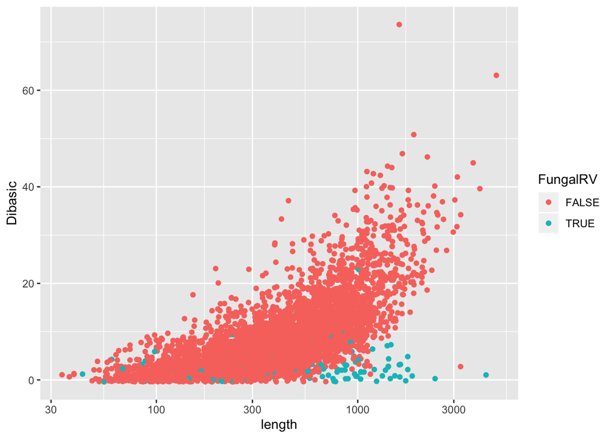

```r
# plot #cysteine and # dibasic peptides against protein length
master %>%
  filter(Species == "C_glabrata") %>%
  ggplot( mapping = aes(x = length, y = Dibasic)) +  geom_jitter(aes( color = FungalRV )) + scale_x_log10()
```

Based on the example above, it seems that the predicted adhesins **do not** have more cysteine or dibasic motifs compared to the rest of the proteins! The plot above clearly suffers from over-plotting. Below I’m trying to make the point by grouping the proteins in the genome into several length bins

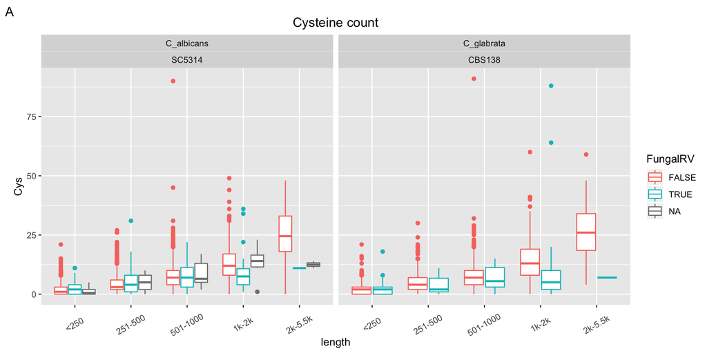

```r
# plot C. albicans and C. glabrata Cysteine content
master %>%
  filter(Species %in% c("C_albicans","C_glabrata")) %>%
  ggplot(mapping = aes(x = binL, y = Cys)) +  geom_boxplot(aes( color = FungalRV )) + facet_wrap(~Species + Strain) + labs(title = "Cysteine count", x = "length", tag = "A") + theme(axis.text.x = element_text(angle = 30, vjust=0.4), plot.title = element_text(hjust = 0.5))
```

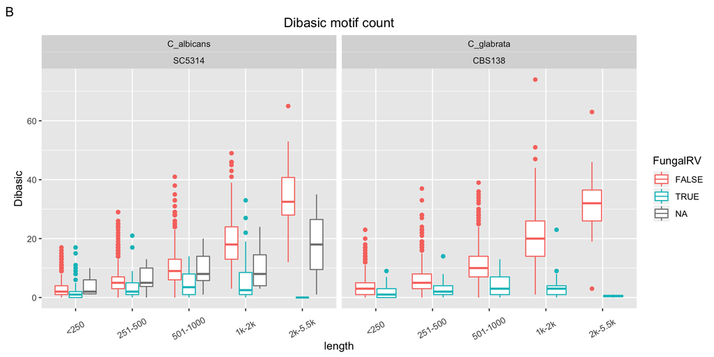

```r
# plot C. albicans and C. glabrata Dibasic content
master %>%
  filter(Species %in% c("C_albicans","C_glabrata")) %>%
  ggplot(mapping = aes(x = binL, y = Dibasic)) +  geom_boxplot(aes( color = FungalRV )) + facet_wrap(~Species + Strain) + labs(title = "Dibasic motif count", x = "length", tag = "B") + theme(axis.text.x = element_text(angle = 30, vjust=0.4), plot.title = element_text(hjust = 0.5))
```

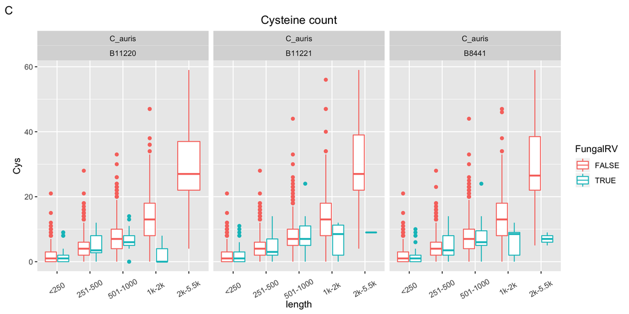

```r
# plot C. auris Cysteine content
master %>%
  filter(Species == c("C_auris")) %>%
  ggplot(mapping = aes(x = binL, y = Cys)) +  geom_boxplot(aes( color = FungalRV )) + facet_wrap(~Species + Strain) + labs(title = "Cysteine count", x = "length", tag = "C") + theme(axis.text.x = element_text(angle = 30, vjust=0.4), plot.title = element_text(hjust = 0.5))
```

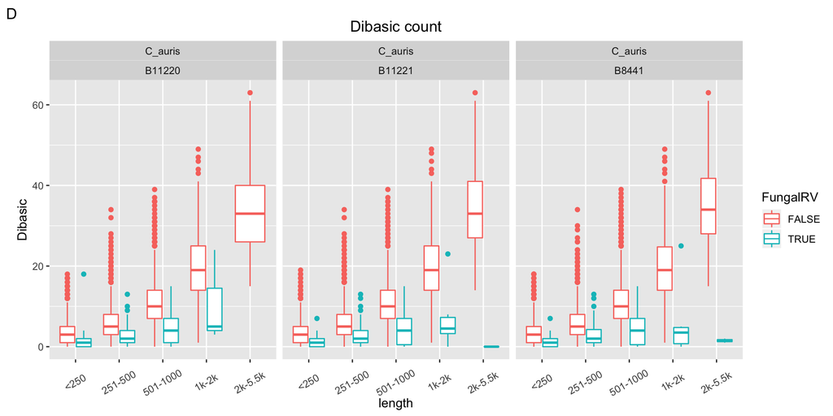

```r
# plot C. auris Dibasic content
master %>%
  filter(Species == c("C_auris")) %>%
  ggplot(mapping = aes(x = binL, y = Dibasic)) +  geom_boxplot(aes( color = FungalRV )) + facet_wrap(~Species + Strain) + labs(title = "Dibasic count", x = "length", tag = "D") + theme(axis.text.x = element_text(angle = 30, vjust=0.4), plot.title = element_text(hjust = 0.5))
```

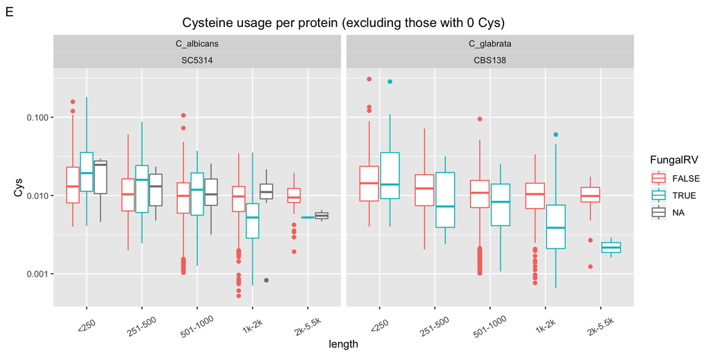

```r
percent <- master %>% mutate(Cys = Cys/length, Dibasic = Dibasic/length)

# plot C. albicans and C. glabrata Cysteine content
percent %>% filter(Cys > 0) %>%
  filter(Species %in% c("C_albicans","C_glabrata")) %>%
  ggplot(mapping = aes(x = binL, y = Cys)) +  geom_boxplot(aes( color = FungalRV )) + facet_wrap(~Species + Strain) + labs(title = "Cysteine usage per protein (excluding those with 0 Cys)", x = "length", tag = "E") + theme(axis.text.x = element_text(angle = 30, vjust=0.4), plot.title = element_text(hjust = 0.5)) + scale_y_log10()
```

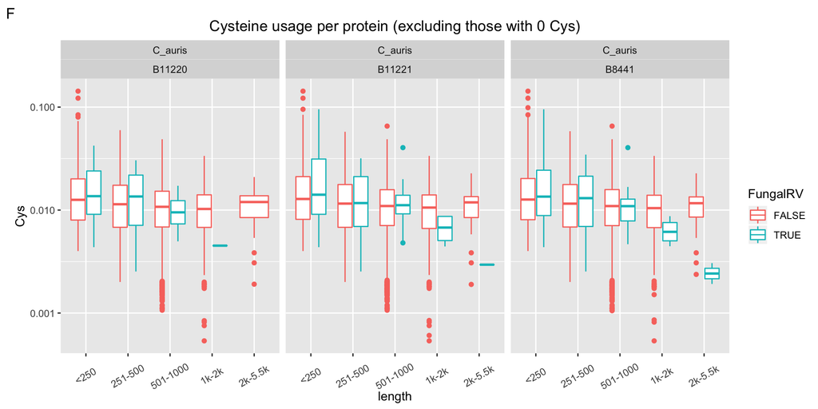

```r
# plot C. auris Cysteine content
percent %>% filter(Cys > 0) %>%
  filter(Species == c("C_auris")) %>%
  ggplot(mapping = aes(x = binL, y = Cys)) +  geom_boxplot(aes( color = FungalRV )) + facet_wrap(~Species + Strain) + labs(title = "Cysteine usage per protein (excluding those with 0 Cys)", x = "length", tag = "F") + theme(axis.text.x = element_text(angle = 30, vjust=0.4), plot.title = element_text(hjust = 0.5)) + scale_y_log10()
```

## Revisit the percentage

Jan suggested comparing the cysteine content as a percentage of the protein length to the naive expectation of 1/20, assuming all 20 amino acids are equally represented.

```r
# first I'd like to get an idea of the genome-wide cysteine percentage
# Across the genome, the cysteine percentage is:
print(master %>% group_by(Species, Strain) %>% summarize(Cys.Usage = sum(Cys)/sum(length)))
```

```
## # A tibble: 5 x 3
## # Groups:   Species [3]
##   Species    Strain Cys.Usage
##   <chr>      <chr>      <dbl>
## 1 C_albicans SC5314    0.0107
## 2 C_auris    B11220    0.0113
## 3 C_auris    B11221    0.0115
## 4 C_auris    B8441     0.0114
## 5 C_glabrata CBS138    0.0116
```

```r
# In the predicted adhesins, the cysteine percentage is:
print(master %>% filter(FungalRV) %>% group_by(Species, Strain) %>% summarize(Cys.Usage = sum(Cys)/sum(length)))
```

```
## # A tibble: 5 x 3
## # Groups:   Species [3]
##   Species    Strain Cys.Usage
##   <chr>      <chr>      <dbl>
## 1 C_albicans SC5314   0.0118
## 2 C_auris    B11220   0.0104
## 3 C_auris    B11221   0.0104
## 4 C_auris    B8441    0.00980
## 5 C_glabrata CBS138   0.00871
```

```r
# A closer look at the distribution of cysteine usage per protein
# First for the genome-wide:
print(master %>% mutate(Cys.perc = Cys / length) %>% group_by(Species, Strain) %>% summarize(min=min(Cys.perc), QT1=quantile(Cys.perc,probs = 0.25), median = median(Cys.perc), QT3 = quantile(Cys.perc, probs = 0.75), max=max(Cys.perc)))
```

```
## # A tibble: 5 x 7
## # Groups:   Species [3]
##   Species    Strain   min     QT1  median    QT3   max
##   <chr>      <chr>  <dbl>   <dbl>   <dbl>  <dbl> <dbl>
## 1 C_albicans SC5314     0 0.00455 0.00930 0.0152 0.182
## 2 C_auris    B11220     0 0.00515 0.0100  0.0157 0.143
## 3 C_auris    B11221     0 0.00531 0.0103  0.0162 0.143
## 4 C_auris    B8441      0 0.00522 0.0102  0.0161 0.143
## 5 C_glabrata CBS138     0 0.00562 0.0107  0.0168 0.308
```

```r
# Next just for the predicted adhesins:
print(master %>% filter(FungalRV) %>% mutate(Cys.perc = Cys / length) %>% group_by(Species, Strain) %>% summarize(min=min(Cys.perc), QT1=quantile(Cys.perc,probs = 0.25), median = median(Cys.perc), QT3 = quantile(Cys.perc, probs = 0.75), max=max(Cys.perc)))
```

```
## # A tibble: 5 x 7
## # Groups:   Species [3]
##   Species    Strain   min     QT1  median    QT3    max
##   <chr>      <chr>  <dbl>   <dbl>   <dbl>  <dbl>  <dbl>
## 1 C_albicans SC5314     0 0.00244 0.00883 0.0206 0.182
## 2 C_auris    B11220     0 0       0.00914 0.0169 0.0423
## 3 C_auris    B11221     0 0.00336 0.00939 0.0168 0.0952
## 4 C_auris    B8441      0 0.00315 0.00928 0.0167 0.0952
## 5 C_glabrata CBS138     0 0.00269 0.00687 0.0143 0.286
```

## Sliding window approach

While looking at the manually annotated adhesin sequences in Lipke 2018, I realized that he used the term “Cys-rich regions” to emphasize the local enrichment of cysteine. This prompted me to use a sliding window approach to take another look. I chose the window size to be 300 a.a. and a step size of 10 a.a. The highest number of Cysteine residues in all sliding windows is recorded and reported.

```r
# load data
cys.window.raw <- read_tsv("all-genome-freq-window.txt", col_names = c("ID","length","Cys","Dibasic"), comment = "#", col_types = "ciii")
cys.window <- cys.window.raw %>% mutate(window = ifelse(length >= 300, 300, length), Cys.w.perc = Cys / window)
master1 <- master %>% left_join(cys.window %>% select(ID, Cys.w.perc))
```

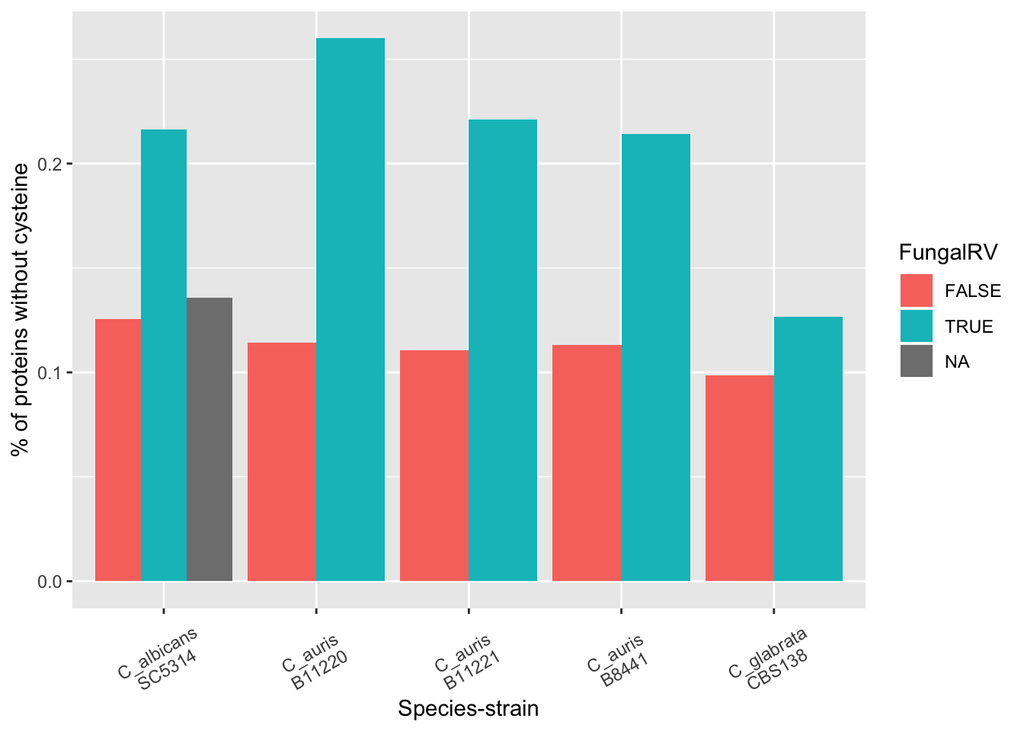

```r
# plot
# First, check the fraction of sequences without cysteine at all
master1 %>%
  group_by(Species, Strain, FungalRV) %>%
  summarize(Frac_no_Cys = sum(Cys==0)/n()) %>%
  ggplot(mapping = aes(x = paste(Species, Strain, sep = "\n"), y = Frac_no_Cys)) +
  geom_col(aes(fill = FungalRV), position = position_dodge()) +
  labs(x = "Species-strain", y = "% of proteins without cysteine") +
  theme(axis.text.x = element_text(angle = 30, vjust=0.4))
```

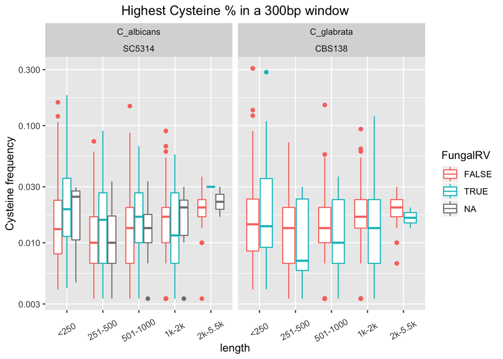

```r
# C. albicans and C. glabrata Cysteine content
master1 %>%
  filter(Species %in% c("C_albicans","C_glabrata"), Cys.w.perc > 0) %>%
  ggplot(mapping = aes(x = binL, y = Cys.w.perc)) +  geom_boxplot(aes( color = FungalRV )) + facet_wrap(~Species + Strain) + labs(title = "Highest Cysteine % in a 300bp window", x = "length", y = "Cysteine frequency") + scale_y_log10() + theme(axis.text.x = element_text(angle = 30, vjust=0.4), plot.title = element_text(hjust = 0.5))
```

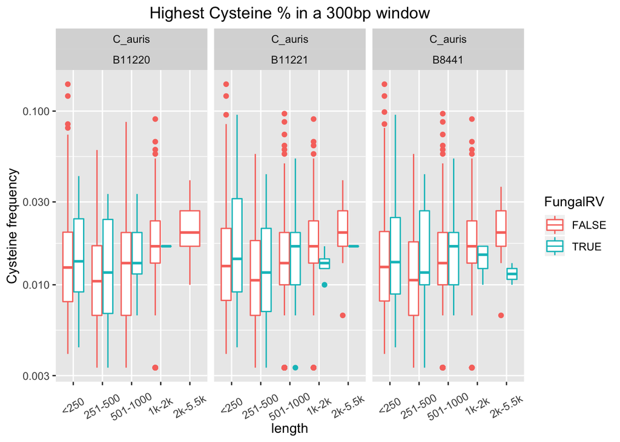

```r
# plot C. auris Cysteine content
master1 %>%
  filter(Species == c("C_auris"), Cys.w.perc > 0) %>%
  ggplot(mapping = aes(x = binL, y = Cys.w.perc)) +  geom_boxplot(aes( color = FungalRV )) + facet_wrap(~Species + Strain) + labs(title = "Highest Cysteine % in a 300bp window", x = "length", y = "Cysteine frequency") + scale_y_log10() + theme(axis.text.x = element_text(angle = 30, vjust=0.4), plot.title = element_text(hjust = 0.5))
```

### Conclusion

In *C. albicans* and *C. auris*, the fraction of adhesins without any cysteine is twice that of the rest of the genome, while in *C. glabrata*, the percentage is slightly higher for predicted adhesins than the rest of the genome.

Among the proteins with cysteine, the mean cysteine percentage in a window size of 300 a.a. appears to be slightly higher in the predicted adhesins than in the rest of the genome in *C. albicans* and *C. auris*, but only for proteins with < 1000 a.a.